[Antonio Schettino](https://www.researchgate.net/profile/Antonio_Schettino2)

2017-04-24

In this project we will investigate the electrophysiological correlates of the combined processing of basic visual properties (i.e., size and contrast) and the emotional content of simple words.

```r
data.EEG.trial <- read.csv(here::here("EEG/pilot/data/pilot_trialEEG.csv"), header = TRUE) # load data

data.EEG.trial <- data.EEG.trial[data.EEG.trial$bin %in% c(1:8), ] # subset trials main experiment

data.EEG.trial$size <- # main effect of size
  revalue(
    factor(data.EEG.trial$bin),
    c(
      "1" = "large", "2" = "small", "3" = "large", "4" = "small",
      "5" = "large", "6" = "small", "7" = "large", "8" = "small"
    )
  )

data.EEG.trial$cont <- # main effect of contrast
  revalue(
    factor(data.EEG.trial$bin),
    c(
      "1" = "dark", "2" = "dark", "3" = "bright", "4" = "bright",
      "5" = "dark", "6" = "dark", "7" = "bright", "8" = "bright"
    )
  )

data.EEG.trial$emo <- # main effect of emotion
  revalue(
    factor(data.EEG.trial$bin),
    c(
      "1" = "negative", "2" = "negative", "3" = "negative", "4" = "negative",
      "5" = "neutral", "6" = "neutral", "7" = "neutral", "8" = "neutral"
    )
  )

data.EEG.trial$bin <- # recode bin variable
  revalue(
    factor(data.EEG.trial$bin),
    c(
      "1" = "negativeLargeDark", "2" = "negativeSmallDark", "3" = "negativeLargeBright", "4" = "negativeSmallBright",
      "5" = "neutralLargeDark", "6" = "neutralSmallDark", "7" = "neutralLargeBright", "8" = "neutralSmallBright"
    )
  )

# add words for each trial
data.EEG.trialWords <- read.csv(here::here("EEG/pilot/data/pilot_words.csv"), header = TRUE) # load data
data.EEG.trial$word <- data.EEG.trialWords[1:1434, "word"] # ends at 1434 because of a bug in extracting the trials in pilot12. hopefully we won't have this problem in the main experimental sample
rm(data.EEG.trialWords) # delete word data

data.EEG.trial <- within(data.EEG.trial, size <- relevel(size, ref = "large")) # reference: large size
data.EEG.trial <- within(data.EEG.trial, cont <- relevel(cont, ref = "dark")) # reference: high contrast
data.EEG.trial <- within(data.EEG.trial, emo <- relevel(emo, ref = "neutral")) # reference: neutral emotion
```

The data we will use in this demo come from a pilot experiment (N = 3).

We will calculate and compare the Bayes Factor of different linear mixed-effects models. The random factors are participants and the individual word per trial. Their variance is set as nuisance.

We will compare (against the null model) the following models:

1. main effects of size and emotion
2. interactive effects of size and emotion
3. main effects of contrast and emotion
4. interactive effects of contrast and emotion
5. main effects of size, contrast, and emotion
6. interactive effects of size, contrast, and emotion

We will then compare the best competing models to understand which one should be preferred overall.

# *P1*

```r
# summarize data
summary.data.EEG.trial <-
  summarySEwithin(
    data.EEG.trial,
    "P1",
    withinvars = c("size", "cont", "emo"),
    idvar = "participant"
  )

kable(summary.data.EEG.trial)
```

| size | cont | emo | N | P1 | sd | se | ci |
| --- | --- | --- | --- | --- | --- | --- | --- |
| large | dark | neutral | 180 | 1.368 | 3.39 | 0.253 | 0.499 |
| large | dark | negative | 180 | 1.630 | 3.42 | 0.255 | 0.503 |
| large | bright | neutral | 179 | 1.235 | 3.43 | 0.256 | 0.506 |
| large | bright | negative | 179 | 0.739 | 3.56 | 0.266 | 0.526 |
| small | dark | neutral | 179 | 1.778 | 3.34 | 0.250 | 0.493 |
| small | dark | negative | 180 | 1.412 | 3.36 | 0.251 | 0.495 |
| small | bright | neutral | 178 | -0.133 | 3.60 | 0.270 | 0.533 |
| small | bright | negative | 179 | -0.096 | 3.29 | 0.246 | 0.485 |

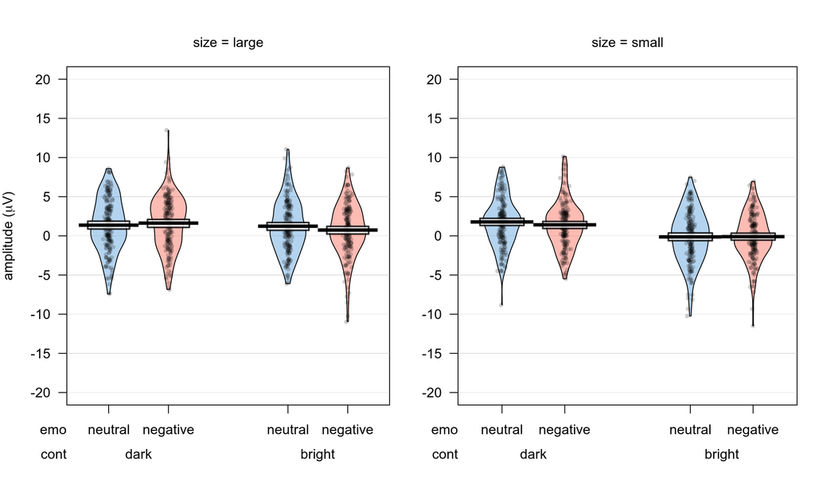

```r
# P1 graph
pirateplot(
  formula = P1 ~ emo + cont + size, # dependent~independent variables
  data = data.EEG.trial, # data frame
  main = "", # main title
  xlim = NULL, # x-axis: limits
  xlab = "", # x-axis: label
  ylim = c(-20, 20), # y-axis: limits
  ylab = expression(paste("amplitude (", mu, "V)")), # y-axis: label
  inf.method = "hdi", # type of inference: 95% Bayesian Highest Density Interval (HDI)
  hdi.iter = 5000, # number of iterations for 95% HDI
  cap.beans = TRUE, # max and min values of bean densities are capped at the limits found in the data
  pal = "xmen" # color palette [see piratepal(palette="all")]
)
```

```r
niter <- 10000 # number of MonteCarlo iterations
scaling.factor <- c(.5, sqrt(2) / 2, 1) # scaling factors of JZS prior: narrow, medium, wide)

compare.P1.BF <- matrix(NA, 6, length(scaling.factor)) # preallocate matrix with all BF10
compare.P1.perc.err <- matrix(NA, 6, length(scaling.factor)) # preallocate matrix with all % errors

for (k in 1:length(scaling.factor)) { # loop through scaling factors

  ### main effects of size and emotion
  P1.sizeplusemo.BF <-
    lmBF(
      P1 ~ size + emo,
      data.EEG.trial,
      whichRandom = c("participant", "word"),
      rscaleFixed = scaling.factor[k],
      rscaleRandom = "nuisance",
      rscaleCont = "medium",
      iterations = niter,
      posterior = FALSE
    )

  ### interactive effects of size and emotion
  P1.sizebyemo.BF <-
    lmBF(
      P1 ~ size:emo,
      data.EEG.trial,
      whichRandom = c("participant", "word"),
      rscaleFixed = scaling.factor[k],
      rscaleRandom = "nuisance",
      rscaleCont = "medium",
      iterations = niter,
      posterior = FALSE
    )

  ### main effects of contrast and emotion
  P1.contplusemo.BF <-
    lmBF(P1 ~ cont + emo,
      data.EEG.trial,
      whichRandom = c("participant", "word"),
      rscaleFixed = scaling.factor[k],
      rscaleRandom = "nuisance",
      rscaleCont = "medium",
      iterations = niter,
      posterior = FALSE
    )

  ### interactive effects of contrast and emotion
  P1.contbyemo.BF <-
    lmBF(
      P1 ~ cont:emo,
      data.EEG.trial,
      whichRandom = c("participant", "word"),
      rscaleFixed = scaling.factor[k],
      rscaleRandom = "nuisance",
      rscaleCont = "medium",
      iterations = niter,
      posterior = FALSE
    )

  ### main effects of size, contrast, and emotion
  P1.sizepluscontplusemo.BF <-
    lmBF(
      P1 ~ size + cont + emo,
      data.EEG.trial,
      whichRandom = c("participant", "word"),
      rscaleFixed = scaling.factor[k],
      rscaleRandom = "nuisance",
      rscaleCont = "medium",
      iterations = niter,
      posterior = FALSE
    )

  ### interactive effects of size, contrast, and emotion
  P1.sizebycontbyemo.BF <-
    lmBF(
      P1 ~ size * cont * emo,
      data.EEG.trial,
      whichRandom = c("participant", "word"),
      rscaleFixed = scaling.factor[k],
      rscaleRandom = "nuisance",
      rscaleCont = "medium",
      iterations = niter,
      posterior = FALSE
    )

  ### model comparison
  # BFs
  compare.P1.BF[, k] <- c(
    exp(1)^P1.sizeplusemo.BF@bayesFactor$bf[1],
    exp(1)^P1.sizebyemo.BF@bayesFactor$bf[1],
    exp(1)^P1.contplusemo.BF@bayesFactor$bf[1],
    exp(1)^P1.contbyemo.BF@bayesFactor$bf[1],
    exp(1)^P1.sizepluscontplusemo.BF@bayesFactor$bf[1],
    exp(1)^P1.sizebycontbyemo.BF@bayesFactor$bf[1]
  )

  # percentage of error
  compare.P1.perc.err[, k] <- c(
    P1.sizeplusemo.BF@bayesFactor$error[1] * 100,
    P1.sizebyemo.BF@bayesFactor$error[1] * 100,
    P1.contplusemo.BF@bayesFactor$error[1] * 100,
    P1.contbyemo.BF@bayesFactor$error[1] * 100,
    P1.sizepluscontplusemo.BF@bayesFactor$error[1] * 100,
    P1.sizebycontbyemo.BF@bayesFactor$error[1] * 100
  )
}

# summary
compare.P1 <-
  data.frame(
    "model" = c("size + emo", "size x emo", "contr + emo", "cont x emo", "size + cont + emo", "size x cont x emo"),
    "nar" = round(compare.P1.BF[, 1], digits = 3), "nar.p.err" = round(compare.P1.perc.err[, 1], digits = 3),
    "med" = round(compare.P1.BF[, 2], digits = 3), "med.p.err" = round(compare.P1.perc.err[, 2], digits = 3),
    "wid" = round(compare.P1.BF[, 3], digits = 3), "wid.p.err" = round(compare.P1.perc.err[, 3], digits = 3)
  )

compare.P1 <- compare.P1[order(compare.P1$med, decreasing = TRUE), ] # sort according to medium scaling factor (in descending order)

kable(compare.P1)
```

|  | model | nar | nar.p.err | med | med.p.err | wid | wid.p.err |
| --- | --- | --- | --- | --- | --- | --- | --- |
| 5 | size + cont + emo | 4473708.274 | 2.620 | 1734990.024 | 2.082 | 690825.068 | 1.611 |
| 3 | contr + emo | 1552622.393 | 15.179 | 740997.920 | 1.666 | 411047.333 | 1.149 |
| 6 | size x cont x emo | 379365.488 | 5.139 | 62065.892 | 29.401 | 3903.303 | 3.933 |
| 1 | size + emo | 0.242 | 1.145 | 0.122 | 1.200 | 0.060 | 1.400 |
| 4 | cont x emo | 0.068 | 0.159 | 0.048 | 0.227 | 0.034 | 0.323 |
| 2 | size x emo | 0.060 | 0.180 | 0.042 | 0.257 | 0.030 | 0.366 |

When using a JZS prior with scaling factor r = 0.707 placed on standardized effect sizes, the model size + cont + emo ought to be preferred.  
The best model (size + cont + emo) explains the observed data 2.341 times better than the second best model (contr + emo).

# *N1*

```r
# summarize data
summary.data.EEG.trial <-
  summarySEwithin(
    data.EEG.trial,
    "N1",
    withinvars = c("size", "cont", "emo"),
    idvar = "participant"
  )

kable(summary.data.EEG.trial)
```

| size | cont | emo | N | N1 | sd | se | ci |
| --- | --- | --- | --- | --- | --- | --- | --- |
| large | dark | neutral | 180 | -3.65 | 3.66 | 0.273 | 0.538 |
| large | dark | negative | 180 | -3.20 | 3.93 | 0.293 | 0.578 |
| large | bright | neutral | 179 | -2.73 | 4.02 | 0.300 | 0.592 |
| large | bright | negative | 179 | -2.30 | 4.22 | 0.316 | 0.623 |
| small | dark | neutral | 179 | -3.44 | 3.85 | 0.288 | 0.567 |
| small | dark | negative | 180 | -3.65 | 3.73 | 0.278 | 0.549 |
| small | bright | neutral | 178 | -0.72 | 3.91 | 0.293 | 0.579 |
| small | bright | negative | 179 | -1.03 | 3.94 | 0.295 | 0.582 |

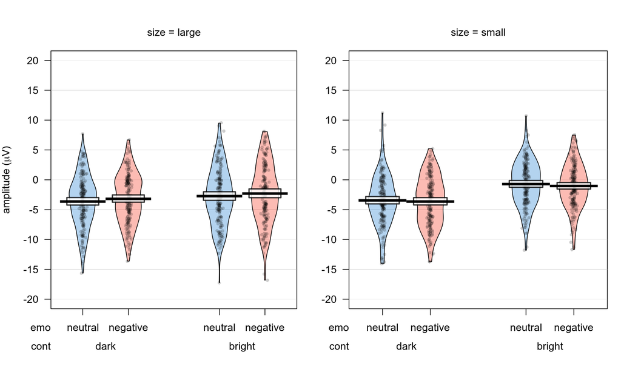

```r
# N1 graph
pirateplot(
  formula = N1 ~ emo + cont + size, # dependent~independent variables
  data = data.EEG.trial, # data frame
  main = "", # main title
  xlim = NULL, # x-axis: limits
  xlab = "", # x-axis: label
  ylim = c(-20, 20), # y-axis: limits
  ylab = expression(paste("amplitude (", mu, "V)")), # y-axis: label
  inf.method = "hdi", # type of inference: 95% Bayesian Highest Density Interval (HDI)
  hdi.iter = 5000, # number of iterations for 95% HDI
  cap.beans = TRUE, # max and min values of bean densities are capped at the limits found in the data
  pal = "xmen" # color palette [see piratepal(palette="all")]
)
```

```r
niter <- 10000 # number of MonteCarlo iterations
scaling.factor <- c(.5, sqrt(2) / 2, 1) # scaling factors of JZS prior: narrow, medium, wide)

compare.N1.BF <- matrix(NA, 6, length(scaling.factor)) # preallocate matrix with all BF10
compare.N1.perc.err <- matrix(NA, 6, length(scaling.factor)) # preallocate matrix with all % errors

for (k in 1:length(scaling.factor)) { # loop through scaling factors

  ### main effects of size and emotion
  N1.sizeplusemo.BF <-
    lmBF(
      N1 ~ size + emo,
      data.EEG.trial,
      whichRandom = c("participant", "word"),
      rscaleFixed = scaling.factor[k],
      rscaleRandom = "nuisance",
      rscaleCont = "medium",
      iterations = niter,
      posterior = FALSE
    )

  ### interactive effects of size and emotion
  N1.sizebyemo.BF <-
    lmBF(
      N1 ~ size:emo,
      data.EEG.trial,
      whichRandom = c("participant", "word"),
      rscaleFixed = scaling.factor[k],
      rscaleRandom = "nuisance",
      rscaleCont = "medium",
      iterations = niter,
      posterior = FALSE
    )

  ### main effects of contrast and emotion
  N1.contplusemo.BF <-
    lmBF(
      N1 ~ cont + emo,
      data.EEG.trial,
      whichRandom = c("participant", "word"),
      rscaleFixed = scaling.factor[k],
      rscaleRandom = "nuisance",
      rscaleCont = "medium",
      iterations = niter,
      posterior = FALSE
    )

  ### interactive effects of contrast and emotion
  N1.contbyemo.BF <-
    lmBF(
      N1 ~ cont:emo,
      data.EEG.trial,
      whichRandom = c("participant", "word"),
      rscaleFixed = scaling.factor[k],
      rscaleRandom = "nuisance",
      rscaleCont = "medium",
      iterations = niter,
      posterior = FALSE
    )

  ### main effects of size, contrast, and emotion
  N1.sizepluscontplusemo.BF <-
    lmBF(
      N1 ~ size + cont + emo,
      data.EEG.trial,
      whichRandom = c("participant", "word"),
      rscaleFixed = scaling.factor[k],
      rscaleRandom = "nuisance",
      rscaleCont = "medium",
      iterations = niter,
      posterior = FALSE
    )

  ### interactive effects of size, contrast, and emotion
  N1.sizebycontbyemo.BF <-
    lmBF(
      N1 ~ size * cont * emo,
      data.EEG.trial,
      whichRandom = c("participant", "word"),
      rscaleFixed = scaling.factor[k],
      rscaleRandom = "nuisance",
      rscaleCont = "medium",
      iterations = niter,
      posterior = FALSE
    )

  ### model comparison
  # BFs
  compare.N1.BF[, k] <- c(
    exp(1)^N1.sizeplusemo.BF@bayesFactor$bf[1],
    exp(1)^N1.sizebyemo.BF@bayesFactor$bf[1],
    exp(1)^N1.contplusemo.BF@bayesFactor$bf[1],
    exp(1)^N1.contbyemo.BF@bayesFactor$bf[1],
    exp(1)^N1.sizepluscontplusemo.BF@bayesFactor$bf[1],
    exp(1)^N1.sizebycontbyemo.BF@bayesFactor$bf[1]
  )

  # percentage of error
  compare.N1.perc.err[, k] <- c(
    N1.sizeplusemo.BF@bayesFactor$error[1] * 100,
    N1.sizebyemo.BF@bayesFactor$error[1] * 100,
    N1.contplusemo.BF@bayesFactor$error[1] * 100,
    N1.contbyemo.BF@bayesFactor$error[1] * 100,
    N1.sizepluscontplusemo.BF@bayesFactor$error[1] * 100,
    N1.sizebycontbyemo.BF@bayesFactor$error[1] * 100
  )
}

# summary
compare.N1 <-
  data.frame(
    "model" = c("size + emo", "size x emo", "contr + emo", "cont x emo", "size + cont + emo", "size x cont x emo"),
    "nar" = round(compare.N1.BF[, 1], digits = 3), "nar.p.err" = round(compare.N1.perc.err[, 1], digits = 3),
    "med" = round(compare.N1.BF[, 2], digits = 3), "med.p.err" = round(compare.N1.perc.err[, 2], digits = 3),
    "wid" = round(compare.N1.BF[, 3], digits = 3), "wid.p.err" = round(compare.N1.perc.err[, 3], digits = 3)
  )

compare.N1 <- compare.N1[order(compare.N1$med, decreasing = TRUE), ] # sort according to medium scaling factor (in descending order)

kable(compare.N1)
```

|  | model | nar | nar.p.err | med | med.p.err | wid | wid.p.err |
| --- | --- | --- | --- | --- | --- | --- | --- |
| 5 | size + cont + emo | 180668364762.707 | 2.199 | 80677356787.061 | 5.273 | 30302708631.196 | 1.606 |
| 3 | contr + emo | 15212555116.082 | 1.006 | 8531436919.496 | 2.046 | 4691402170.392 | 2.350 |
| 6 | size x cont x emo | 63593278607.766 | 3.900 | 7734538084.780 | 21.203 | 743678375.573 | 8.641 |
| 1 | size + emo | 0.872 | 27.025 | 0.334 | 7.876 | 0.162 | 1.190 |
| 2 | size x emo | 0.175 | 0.062 | 0.125 | 0.088 | 0.089 | 0.124 |
| 4 | cont x emo | 0.060 | 0.180 | 0.042 | 0.258 | 0.030 | 0.366 |

When using a JZS prior with scaling factor r = 0.707 placed on standardized effect sizes, the model size + cont + emo ought to be preferred.  
The best model (size + cont + emo) explains the observed data 9.456 times better than the second best model (contr + emo).

# *EPN*

```r
# summarize data
summary.data.EEG.trial <-
  summarySEwithin(
    data.EEG.trial,
    "EPN",
    withinvars = c("size", "cont", "emo"),
    idvar = "participant"
  )

kable(summary.data.EEG.trial)
```

| size | cont | emo | N | EPN | sd | se | ci |
| --- | --- | --- | --- | --- | --- | --- | --- |
| large | dark | neutral | 180 | -1.39 | 3.71 | 0.277 | 0.546 |
| large | dark | negative | 180 | -1.06 | 3.68 | 0.275 | 0.542 |
| large | bright | neutral | 179 | -2.69 | 4.11 | 0.307 | 0.605 |
| large | bright | negative | 179 | -2.46 | 3.73 | 0.279 | 0.550 |
| small | dark | neutral | 179 | -1.16 | 4.08 | 0.305 | 0.602 |
| small | dark | negative | 180 | -1.84 | 3.53 | 0.263 | 0.519 |
| small | bright | neutral | 178 | -1.41 | 4.11 | 0.308 | 0.607 |
| small | bright | negative | 179 | -1.77 | 3.85 | 0.288 | 0.568 |

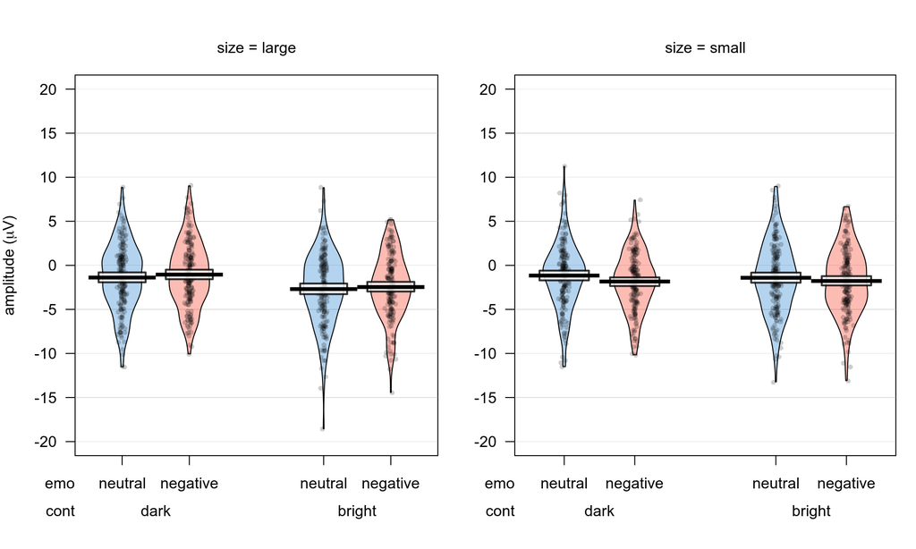

```r
# EPN graph
pirateplot(
  formula = EPN ~ emo + cont + size, # dependent~independent variables
  data = data.EEG.trial, # data frame
  main = "", # main title
  xlim = NULL, # x-axis: limits
  xlab = "", # x-axis: label
  ylim = c(-20, 20), # y-axis: limits
  ylab = expression(paste("amplitude (", mu, "V)")), # y-axis: label
  inf.method = "hdi", # type of inference: 95% Bayesian Highest Density Interval (HDI)
  hdi.iter = 5000, # number of iterations for 95% HDI
  cap.beans = TRUE, # max and min values of bean densities are capped at the limits found in the data
  pal = "xmen" # color palette [see piratepal(palette="all")]
)
```

```r
niter <- 10000 # number of MonteCarlo iterations
scaling.factor <- c(.5, sqrt(2) / 2, 1) # scaling factors of JZS prior: narrow, medium, wide)

compare.EPN.BF <- matrix(NA, 6, length(scaling.factor)) # preallocate matrix with all BF10
compare.EPN.perc.err <- matrix(NA, 6, length(scaling.factor)) # preallocate matrix with all % errors

for (k in 1:length(scaling.factor)) { # loop through scaling factors

  ### main effects of size and emotion
  EPN.sizeplusemo.BF <-
    lmBF(
      EPN ~ size + emo,
      data.EEG.trial,
      whichRandom = c("participant", "word"),
      rscaleFixed = scaling.factor[k],
      rscaleRandom = "nuisance",
      rscaleCont = "medium",
      iterations = niter,
      posterior = FALSE
    )

  ### interactive effects of size and emotion
  EPN.sizebyemo.BF <-
    lmBF(
      EPN ~ size:emo,
      data.EEG.trial,
      whichRandom = c("participant", "word"),
      rscaleFixed = scaling.factor[k],
      rscaleRandom = "nuisance",
      rscaleCont = "medium",
      iterations = niter,
      posterior = FALSE
    )

  ### main effects of contrast and emotion
  EPN.contplusemo.BF <-
    lmBF(
      EPN ~ cont + emo,
      data.EEG.trial,
      whichRandom = c("participant", "word"),
      rscaleFixed = scaling.factor[k],
      rscaleRandom = "nuisance",
      rscaleCont = "medium",
      iterations = niter,
      posterior = FALSE
    )

  ### interactive effects of contrast and emotion
  EPN.contbyemo.BF <-
    lmBF(
      EPN ~ cont:emo,
      data.EEG.trial,
      whichRandom = c("participant", "word"),
      rscaleFixed = scaling.factor[k],
      rscaleRandom = "nuisance",
      rscaleCont = "medium",
      iterations = niter,
      posterior = FALSE
    )

  ### main effects of size, contrast, and emotion
  EPN.sizepluscontplusemo.BF <-
    lmBF(
      EPN ~ size + cont + emo,
      data.EEG.trial,
      whichRandom = c("participant", "word"),
      rscaleFixed = scaling.factor[k],
      rscaleRandom = "nuisance",
      rscaleCont = "medium",
      iterations = niter,
      posterior = FALSE
    )

  ### interactive effects of size, contrast, and emotion
  EPN.sizebycontbyemo.BF <-
    lmBF(
      EPN ~ size * cont * emo,
      data.EEG.trial,
      whichRandom = c("participant", "word"),
      rscaleFixed = scaling.factor[k],
      rscaleRandom = "nuisance",
      rscaleCont = "medium",
      iterations = niter,
      posterior = FALSE
    )

  ### model comparison
  # BFs
  compare.EPN.BF[, k] <- c(
    exp(1)^EPN.sizeplusemo.BF@bayesFactor$bf[1],
    exp(1)^EPN.sizebyemo.BF@bayesFactor$bf[1],
    exp(1)^EPN.contplusemo.BF@bayesFactor$bf[1],
    exp(1)^EPN.contbyemo.BF@bayesFactor$bf[1],
    exp(1)^EPN.sizepluscontplusemo.BF@bayesFactor$bf[1],
    exp(1)^EPN.sizebycontbyemo.BF@bayesFactor$bf[1]
  )

  # percentage of error
  compare.EPN.perc.err[, k] <- c(
    EPN.sizeplusemo.BF@bayesFactor$error[1] * 100,
    EPN.sizebyemo.BF@bayesFactor$error[1] * 100,
    EPN.contplusemo.BF@bayesFactor$error[1] * 100,
    EPN.contbyemo.BF@bayesFactor$error[1] * 100,
    EPN.sizepluscontplusemo.BF@bayesFactor$error[1] * 100,
    EPN.sizebycontbyemo.BF@bayesFactor$error[1] * 100
  )
}

# summary
compare.EPN <-
  data.frame(
    "model" = c("size + emo", "size x emo", "contr + emo", "cont x emo", "size + cont + emo", "size x cont x emo"),
    "nar" = round(compare.EPN.BF[, 1], digits = 3), "nar.p.err" = round(compare.EPN.perc.err[, 1], digits = 3),
    "med" = round(compare.EPN.BF[, 2], digits = 3), "med.p.err" = round(compare.EPN.perc.err[, 2], digits = 3),
    "wid" = round(compare.EPN.BF[, 3], digits = 3), "wid.p.err" = round(compare.EPN.perc.err[, 3], digits = 3)
  )

compare.EPN <- compare.EPN[order(compare.EPN$med, decreasing = TRUE), ] # sort according to medium scaling factor (in descending order)

kable(compare.EPN)
```

|  | model | nar | nar.p.err | med | med.p.err | wid | wid.p.err |
| --- | --- | --- | --- | --- | --- | --- | --- |
| 3 | contr + emo | 2.681 | 1.654 | 1.471 | 1.150 | 0.743 | 3.162 |
| 2 | size x emo | 0.418 | 0.026 | 0.299 | 0.037 | 0.213 | 0.052 |
| 5 | size + cont + emo | 0.757 | 5.302 | 0.281 | 5.910 | 0.105 | 5.319 |
| 4 | cont x emo | 0.061 | 0.176 | 0.043 | 0.252 | 0.031 | 0.358 |
| 1 | size + emo | 0.018 | 1.479 | 0.010 | 3.865 | 0.005 | 1.356 |
| 6 | size x cont x emo | 0.058 | 8.098 | 0.006 | 4.298 | 0.001 | 5.607 |

When using a JZS prior with scaling factor r = 0.707 placed on standardized effect sizes, the model contr + emo ought to be preferred.  
The best model (contr + emo) explains the observed data 4.92 times better than the second best model (size x emo).

# *LPP*

```r
# summarize data
summary.data.EEG.trial <-
  summarySEwithin(
    data.EEG.trial,
    "LPP",
    withinvars = c("size", "cont", "emo"),
    idvar = "participant"
  )

kable(summary.data.EEG.trial)
```

| size | cont | emo | N | LPP | sd | se | ci |
| --- | --- | --- | --- | --- | --- | --- | --- |
| large | dark | neutral | 180 | 0.389 | 2.54 | 0.189 | 0.374 |
| large | dark | negative | 180 | 0.884 | 2.26 | 0.168 | 0.332 |
| large | bright | neutral | 179 | 0.748 | 2.12 | 0.158 | 0.313 |
| large | bright | negative | 179 | 1.154 | 2.50 | 0.187 | 0.368 |
| small | dark | neutral | 179 | 0.403 | 2.48 | 0.185 | 0.365 |
| small | dark | negative | 180 | 0.248 | 2.43 | 0.181 | 0.358 |
| small | bright | neutral | 178 | 0.807 | 2.53 | 0.190 | 0.374 |
| small | bright | negative | 179 | 0.743 | 2.39 | 0.179 | 0.353 |

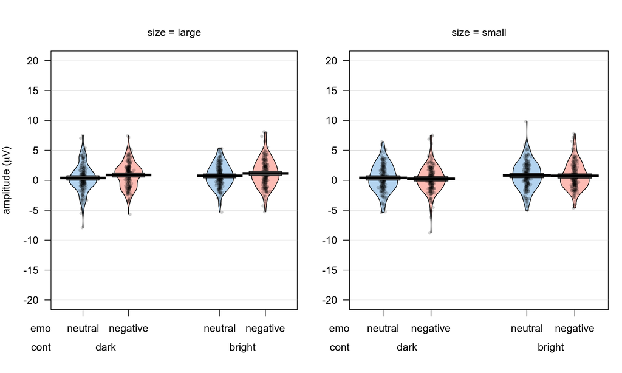

```r
# LPP graph
pirateplot(
  formula = LPP ~ emo + cont + size, # dependent~independent variables
  data = data.EEG.trial, # data frame
  main = "", # main title
  xlim = NULL, # x-axis: limits
  xlab = "", # x-axis: label
  ylim = c(-20, 20), # y-axis: limits
  ylab = expression(paste("amplitude (", mu, "V)")), # y-axis: label
  inf.method = "hdi", # type of inference: 95% Bayesian Highest Density Interval (HDI)
  hdi.iter = 5000, # number of iterations for 95% HDI
  cap.beans = TRUE, # max and min values of bean densities are capped at the limits found in the data
  pal = "xmen" # color palette [see piratepal(palette="all")]
)
```

```r
niter <- 10000 # number of MonteCarlo iterations
scaling.factor <- c(.5, sqrt(2) / 2, 1) # scaling factors of JZS prior: narrow, medium, wide)

compare.LPP.BF <- matrix(NA, 6, length(scaling.factor)) # preallocate matrix with all BF10
compare.LPP.perc.err <- matrix(NA, 6, length(scaling.factor)) # preallocate matrix with all % errors

for (k in 1:length(scaling.factor)) { # loop through scaling factors

  ### main effects of size and emotion
  LPP.sizeplusemo.BF <-
    lmBF(
      LPP ~ size + emo,
      data.EEG.trial,
      whichRandom = c("participant", "word"),
      rscaleFixed = scaling.factor[k],
      rscaleRandom = "nuisance",
      rscaleCont = "medium",
      iterations = niter,
      posterior = FALSE
    )

  ### interactive effects of size and emotion
  LPP.sizebyemo.BF <-
    lmBF(
      LPP ~ size:emo,
      data.EEG.trial,
      whichRandom = c("participant", "word"),
      rscaleFixed = scaling.factor[k],
      rscaleRandom = "nuisance",
      rscaleCont = "medium",
      iterations = niter,
      posterior = FALSE
    )

  ### main effects of contrast and emotion
  LPP.contplusemo.BF <-
    lmBF(
      LPP ~ cont + emo,
      data.EEG.trial,
      whichRandom = c("participant", "word"),
      rscaleFixed = scaling.factor[k],
      rscaleRandom = "nuisance",
      rscaleCont = "medium",
      iterations = niter,
      posterior = FALSE
    )

  ### interactive effects of contrast and emotion
  LPP.contbyemo.BF <-
    lmBF(
      LPP ~ cont:emo,
      data.EEG.trial,
      whichRandom = c("participant", "word"),
      rscaleFixed = scaling.factor[k],
      rscaleRandom = "nuisance",
      rscaleCont = "medium",
      iterations = niter,
      posterior = FALSE
    )

  ### main effects of size, contrast, and emotion
  LPP.sizepluscontplusemo.BF <-
    lmBF(
      LPP ~ size + cont + emo,
      data.EEG.trial,
      whichRandom = c("participant", "word"),
      rscaleFixed = scaling.factor[k],
      rscaleRandom = "nuisance",
      rscaleCont = "medium",
      iterations = niter,
      posterior = FALSE
    )

  ### interactive effects of size, contrast, and emotion
  LPP.sizebycontbyemo.BF <-
    lmBF(
      LPP ~ size * cont * emo,
      data.EEG.trial,
      whichRandom = c("participant", "word"),
      rscaleFixed = scaling.factor[k],
      rscaleRandom = "nuisance",
      rscaleCont = "medium",
      iterations = niter,
      posterior = FALSE
    )

  ### model comparison
  # BFs
  compare.LPP.BF[, k] <- c(
    exp(1)^LPP.sizeplusemo.BF@bayesFactor$bf[1],
    exp(1)^LPP.sizebyemo.BF@bayesFactor$bf[1],
    exp(1)^LPP.contplusemo.BF@bayesFactor$bf[1],
    exp(1)^LPP.contbyemo.BF@bayesFactor$bf[1],
    exp(1)^LPP.sizepluscontplusemo.BF@bayesFactor$bf[1],
    exp(1)^LPP.sizebycontbyemo.BF@bayesFactor$bf[1]
  )

  # percentage of error
  compare.LPP.perc.err[, k] <- c(
    LPP.sizeplusemo.BF@bayesFactor$error[1] * 100,
    LPP.sizebyemo.BF@bayesFactor$error[1] * 100,
    LPP.contplusemo.BF@bayesFactor$error[1] * 100,
    LPP.contbyemo.BF@bayesFactor$error[1] * 100,
    LPP.sizepluscontplusemo.BF@bayesFactor$error[1] * 100,
    LPP.sizebycontbyemo.BF@bayesFactor$error[1] * 100
  )
}

# summary
compare.LPP <-
  data.frame(
    "model" = c("size + emo", "size x emo", "contr + emo", "cont x emo", "size + cont + emo", "size x cont x emo"),
    "nar" = round(compare.LPP.BF[, 1], digits = 3), "nar.p.err" = round(compare.LPP.perc.err[, 1], digits = 3),
    "med" = round(compare.LPP.BF[, 2], digits = 3), "med.p.err" = round(compare.LPP.perc.err[, 2], digits = 3),
    "wid" = round(compare.LPP.BF[, 3], digits = 3), "wid.p.err" = round(compare.LPP.perc.err[, 3], digits = 3)
  )

compare.LPP <- compare.LPP[order(compare.LPP$med, decreasing = TRUE), ] # sort according to medium scaling factor (in descending order)

kable(compare.LPP)
```

|  | model | nar | nar.p.err | med | med.p.err | wid | wid.p.err |
| --- | --- | --- | --- | --- | --- | --- | --- |
| 3 | contr + emo | 1.413 | 1.396 | 0.754 | 3.510 | 0.389 | 4.243 |
| 2 | size x emo | 0.891 | 0.012 | 0.641 | 0.017 | 0.457 | 0.024 |
| 5 | size + cont + emo | 0.693 | 5.685 | 0.253 | 1.622 | 0.087 | 2.329 |
| 4 | cont x emo | 0.059 | 0.182 | 0.042 | 0.260 | 0.030 | 0.370 |
| 1 | size + emo | 0.072 | 2.623 | 0.038 | 4.450 | 0.018 | 1.365 |
| 6 | size x cont x emo | 0.001 | 7.190 | 0.000 | 4.155 | 0.000 | 3.572 |